# water_affordability_map

Chenhui Zhang

2023-08-28

# **Water Price on Map**

The water price map displays the 2022 average water prices for each state, with data sourced from utility bills. Higher values on the map indicate correspondingly higher water prices (in US Dollars).

The map indicates that West Virginia has the highest average water price, while Vermont and Wisconsin have the lowest average water prices.

The interactive map offers several features, including zooming in and out, hovering over each state to reveal water prices, clicking on states for in-depth information, and modifying map layers by selecting the layer icon on the left. These layers include options like dark mode, street map, satellite map, and open topo map.

[interactive chart not shown]

# **Water Price Rank on Map**

The water price ranking is determined by the cost of water, with the top-ranked state having the highest water expenses.

Ranking water prices by state facilitates a more straightforward comparison with water quality because it aligns the scale of both indicators.

[interactive chart not shown]

# **Water Quality Rank on Map**

Water quality is influenced by numerous indicators, making it challenging to achieve a comprehensive evaluation. In response, US News has offered a comprehensive ranking for each state in the year 2022, simplifying the process of visualizing water quality, where the top-ranked state has the best water quality.

[interactive chart not shown]

# **Water Affordability**

Water affordability is comprehensively assessed by considering both price and quality. When a state has a combination of high water prices and low water quality, it indicates lower water affordability. To account for both variables, we introduce the water price/quality rank ratio. A ratio greater than 1 suggests that the state has relatively lower water prices and better water quality. Conversely, a ratio less than 1 indicates higher water prices coupled with worse water quality.

The tables below display states categorized by their high and low price/quality ratios respectively.

## p/q > 1

| state | Price_Rank | Quality_Rank | pqratio |
| --- | --- | --- | --- |
| Alabama | 33 | 2 | 16.500000 |
| Hawaii | 9 | 1 | 9.000000 |
| South Carolina | 25 | 4 | 6.250000 |
| Georgia | 36 | 7 | 5.142857 |
| Tennessee | 14 | 3 | 4.666667 |
| Massachusetts | 23 | 5 | 4.600000 |
| Mississippi | 46 | 13 | 3.538461 |
| Ohio | 39 | 12 | 3.250000 |
| Florida | 25 | 8 | 3.125000 |
| North Carolina | 48 | 16 | 3.000000 |
| Minnesota | 36 | 14 | 2.571429 |
| Nevada | 43 | 18 | 2.388889 |
| Illinois | 43 | 22 | 1.954546 |
| New York | 33 | 17 | 1.941177 |
| Wisconsin | 50 | 26 | 1.923077 |
| Nebraska | 46 | 24 | 1.916667 |
| Kentucky | 11 | 6 | 1.833333 |
| Arkansas | 43 | 27 | 1.592593 |
| North Dakota | 30 | 19 | 1.578947 |
| South Dakota | 43 | 30 | 1.433333 |
| Virginia | 21 | 15 | 1.400000 |
| Louisiana | 47 | 35 | 1.342857 |
| Rhode Island | 28 | 21 | 1.333333 |
| Delaware | 13 | 10 | 1.300000 |
| Maryland | 13 | 11 | 1.181818 |
| Kansas | 39 | 34 | 1.147059 |
| Vermont | 50 | 46 | 1.086957 |

## p/q < 1

| state | Price_Rank | Quality_Rank | pqratio |
| --- | --- | --- | --- |
| West Virginia | 1 | 47 | 0.0212766 |
| Oregon | 3 | 39 | 0.0769231 |
| Alaska | 7 | 50 | 0.1400000 |
| Connecticut | 6 | 37 | 0.1621622 |
| Washington | 4 | 23 | 0.1739130 |
| New Jersey | 5 | 25 | 0.2000000 |
| California | 2 | 9 | 0.2222222 |
| Wyoming | 10 | 44 | 0.2272727 |
| Arizona | 9 | 32 | 0.2812500 |
| Montana | 19 | 48 | 0.3958333 |
| Idaho | 19 | 42 | 0.4523810 |
| Colorado | 16 | 33 | 0.4848485 |
| Oklahoma | 22 | 45 | 0.4888889 |
| Texas | 20 | 31 | 0.6451613 |
| New Mexico | 28 | 43 | 0.6511628 |
| Utah | 19 | 29 | 0.6551724 |
| Pennsylvania | 30 | 40 | 0.7500000 |
| Missouri | 16 | 20 | 0.8000000 |
| Indiana | 33 | 38 | 0.8684211 |
| Maine | 44 | 49 | 0.8979592 |
| Michigan | 34 | 36 | 0.9444444 |
| New Hampshire | 39 | 41 | 0.9512195 |

# Correlations between Water Price and Water Quality

```
##
##  Spearman's rank correlation rho
##
## data:  water$Price_Rank and water$Quality_Rank
## S = 20799, p-value = 0.9931
## alternative hypothesis: true rho is not equal to 0
## sample estimates:
##        rho
## 0.00124952
```

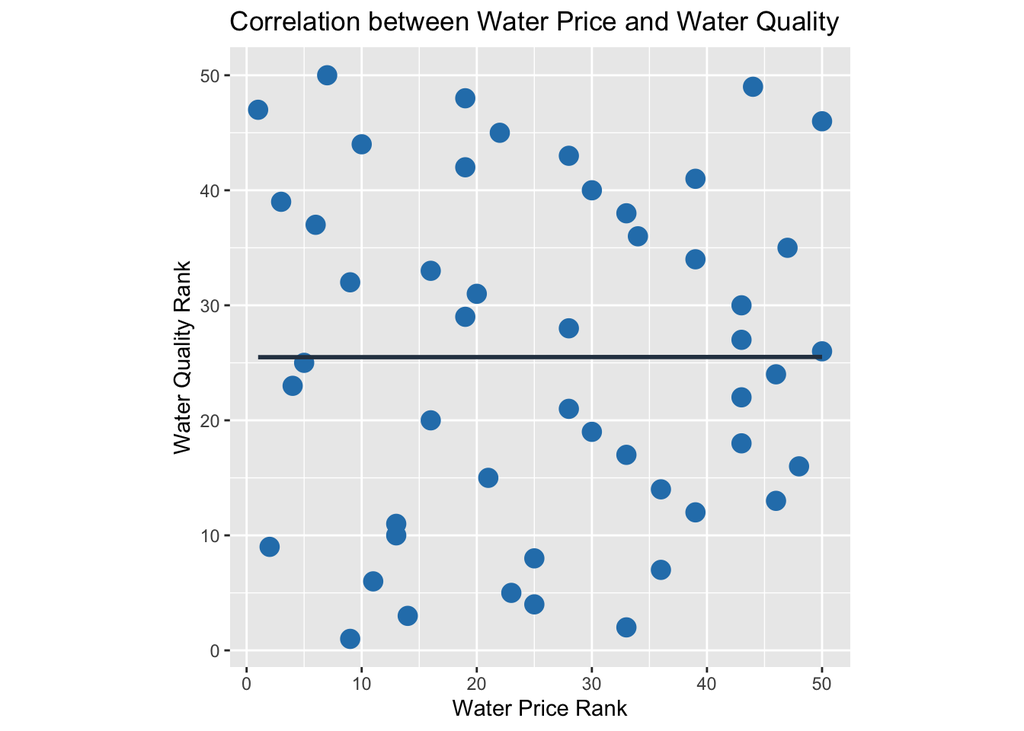

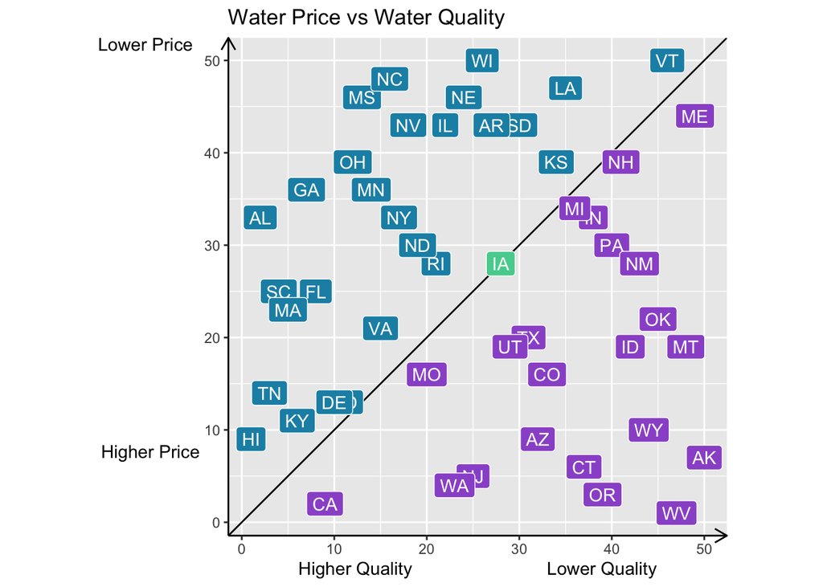

# **Water Affordability on Map**

Examining the spatial distribution of the p/q ratio reveals notable patterns in water affordability. In many western states, the p/q ratio is below 1, suggesting that water tends to be less affordable in these areas. In contrast, in some eastern states, the p/q ratio exceeds 1, indicating a higher level of affordability, often associated with relatively lower costs and improved water quality.

[interactive chart not shown]

Enhancing overall water affordability necessitates a concerted effort to simultaneously enhance water quality and reduce water prices. These two facets are intrinsically linked, and addressing them in tandem can lead to more equitable access to clean and reasonably priced water resources.

By using the map, we can identify areas where there are specific issues related to water quality and pricing. This helps policymakers, water management authorities, and community groups target their efforts more effectively. It allows them to create strategies that are tailored to the unique challenges each state faces, ultimately making water more accessible and ensuring it meets high-quality standards. This way, we can protect the health and well-being of people all across the country.

*Reference*

*https://worldpopulationreview.com/state-rankings/water-prices-by-state*

*https://www.infoworld.com/article/3644848/astonishingly-easy-mapping-in-r-with-mapview.html*

*https://r-graph-gallery.com/183-choropleth-map-with-leaflet.html*

*https://www.usnews.com/news/best-states/rankings/natural-environment/air-water-quality/drinking-water-quality*